# Bài 16

Tran Tien Dat

2025-11-20

# About MobileAds dataset

## Load data

```r
mobile_ads = read_csv("data/MobileAds.csv")
glimpse(mobile_ads)
```

```
## Rows: 655
## Columns: 40
## $ Campaign       <dbl> 1, 2, 3, 4, 5, 6, 7, 8, 9, 10, 11, 12, 13, 14, 15, 16, …
## $ m.impr_post    <dbl> 255, 18, 583, 11498, 1554, 1886, 4859, 1015, 21, 534, 1…
## $ m.impr_pre     <dbl> 155, 4900, 6858, 3439, 1549, 1159, 891, 347, 72, 473, 1…
## $ m.click_post   <dbl> 3, 1, 2, 151, 28, 62, 57, 19, 0, 23, 2, 2, 1, 1, 33, 3,…
## $ m.click_pre    <dbl> 3, 41, 46, 36, 34, 35, 7, 11, 7, 31, 17, 10, 5, 13, 12,…
## $ m.cost_post    <dbl> 148.53, 4.50, 8.17, 500.93, 90.37, 1166.75, 228.15, 43.…
## $ m.cost_pre     <dbl> 94.38, 395.32, 162.05, 105.69, 86.97, 699.00, 17.91, 23…
## $ m.conv_post    <dbl> 0, 0, 0, 13, 1, 40, 0, 2, 0, 3, 0, 0, 0, 0, 3, 0, 1, 3,…
## $ m.conv_pre     <dbl> 4, 2, 2, 6, 6, 28, 4, 6, 5, 10, 8, 4, 3, 4, 5, 3, 6, 5,…
## $ m.value_post   <dbl> 0.00, 0.00, 0.00, 405.40, 0.00, 1097.60, 0.00, 9.50, 0.…
## $ m.value_pre    <dbl> 193.00, 231.57, 46.30, 395.90, 141.77, 1240.41, 212.55,…
## $ m.cpm_pre      <dbl> 0.608903226, 0.080677551, 0.023629338, 0.030732771, 0.0…
## $ m.cpm_post     <dbl> 0.582470588, 0.250000000, 0.014013722, 0.043566707, 0.0…
```

[output cut: 27 more lines]

# Exploration

## Re-format dataframe

```r
summary_table <- mobile_ads |> select(where(is.numeric)) |>
  summarize(across(everything(), list(
    mean = mean,
    median = median,
    sd = sd,
    min = min,
    max = max
  ), na.rm = TRUE, .names = "{.col}#{.fn}")) |>
  pivot_longer(cols = everything(),
               names_to = "name",
               values_to = "value") |>
  separate(name, into = c("variable", "stat"), sep = "\\#") |>
  pivot_wider( names_from = variable, values_from = value)
summary_table
```

```
## # A tibble: 5 × 41
##   stat   Campaign m.impr_post m.impr_pre m.click_post m.click_pre m.cost_post
##   <chr>     <dbl>       <dbl>      <dbl>        <dbl>       <dbl>       <dbl>
## 1 mean       328        2287.      2626.         66.9        75.2       117.
## 2 median     328         901       1187          23          32          43.7
## 3 sd         189.       4878.      5078.        212.        208.        243.
## 4 min          1           0         52           0           2           0
## 5 max        655       72804      64678        4053        3895        2681.
## # ℹ 34 more variables: m.cost_pre <dbl>, m.conv_post <dbl>, m.conv_pre <dbl>,
## #   m.value_post <dbl>, m.value_pre <dbl>, m.cpm_pre <dbl>, m.cpm_post <dbl>,
## #   m.cpc_pre <dbl>, m.cpc_post <dbl>, m.cpa_pre <dbl>, m.cpa_post <dbl>,
## #   m.cpr_pre <dbl>, m.cpr_post <dbl>, mult.change <dbl>, d.impr_post <dbl>,
## #   d.impr_pre <dbl>, d.click_post <dbl>, d.click_pre <dbl>, d.cost_post <dbl>,
## #   d.cost_pre <dbl>, d.conv_post <dbl>, d.conv_pre <dbl>, d.value_post <dbl>,
## #   d.value_pre <dbl>, d.cpm_pre <dbl>, d.cpm_post <dbl>, d.cpc_pre <dbl>, …
```

```r
data_a <- mobile_ads |>
  select(Campaign,contains("error.cpr"))

head(data_a)
```

```
## # A tibble: 6 × 3
##   Campaign error.cpr_pre error.cpr_post
##      <dbl>         <dbl>          <dbl>
## 1        1         0.489          1.23
## 2        2         0.661          1.43
## 3        3         2.62           1.21
## 4        4         0.267          1.24
## 5        5         0.128          1.94
## 6        6         0.139          0.251
```

```r
data_b <- mobile_ads |> select(- mult.change & -error.cpr_pre & -error.cpr_post)

head(data_b)
```

```
## # A tibble: 6 × 37
##   Campaign m.impr_post m.impr_pre m.click_post m.click_pre m.cost_post
##      <dbl>       <dbl>      <dbl>        <dbl>       <dbl>       <dbl>
## 1        1         255        155            3           3      149.
## 2        2          18       4900            1          41        4.5
## 3        3         583       6858            2          46        8.17
## 4        4       11498       3439          151          36      501.
## 5        5        1554       1549           28          34       90.4
## 6        6        1886       1159           62          35     1167.
## # ℹ 31 more variables: m.cost_pre <dbl>, m.conv_post <dbl>, m.conv_pre <dbl>,
## #   m.value_post <dbl>, m.value_pre <dbl>, m.cpm_pre <dbl>, m.cpm_post <dbl>,
## #   m.cpc_pre <dbl>, m.cpc_post <dbl>, m.cpa_pre <dbl>, m.cpa_post <dbl>,
## #   m.cpr_pre <dbl>, m.cpr_post <dbl>, d.impr_post <dbl>, d.impr_pre <dbl>,
## #   d.click_post <dbl>, d.click_pre <dbl>, d.cost_post <dbl>, d.cost_pre <dbl>,
## #   d.conv_post <dbl>, d.conv_pre <dbl>, d.value_post <dbl>, d.value_pre <dbl>,
## #   d.cpm_pre <dbl>, d.cpm_post <dbl>, d.cpc_pre <dbl>, d.cpc_post <dbl>, …
```

```r
data_b <- data_b |>
  pivot_longer(
    cols = -Campaign,
    names_to = "variable",
    values_to = "value"
  ) |>
  separate(
    col = variable,
    into = c("platform", "stat", "time"),
    sep = "[._]"
  ) |>
  pivot_wider(names_from = stat)

data_b
```

```
## # A tibble: 2,620 × 12
##    Campaign platform time   impr click    cost  conv  value    cpm   cpc   cpa
##       <dbl> <chr>    <chr> <dbl> <dbl>   <dbl> <dbl>  <dbl>  <dbl> <dbl> <dbl>
##  1        1 m        post    255     3  149.       0    0   0.582  49.5    0
##  2        1 m        pre     155     3   94.4      4  193   0.609  31.5   23.6
##  3        1 d        post   1466    22  703.       9  570   0.480  32.0   78.2
##  4        1 d        pre    1430    15  482.       2    0   0.337  32.1  241.
##  5        2 m        post     18     1    4.5      0    0   0.25    4.5    0
##  6        2 m        pre    4900    41  395.       2  232.  0.0807  9.64 198.
##  7        2 d        post  64535   348 5143.      51 3589.  0.0797 14.8  101.
##  8        2 d        pre   54535   297 4085.      60 3905.  0.0749 13.8   68.1
##  9        3 m        post    583     2    8.17     0    0   0.0140  4.08   0
## 10        3 m        pre    6858    46  162.       2   46.3 0.0236  3.52  81.0
## # ℹ 2,610 more rows
## # ℹ 1 more variable: cpr <dbl>
```

# Problems

## 1.1 Question

> What is the number of cpc equal to 0 in mobile platform during experiments ?

## 1.2 Ans

```r
cpc_m_zero <- data_b |>
  filter(time == "post", cpc == 0, platform == "m")

cpc_m <- data_b |>
  filter(time == "post", platform == "m")

cpc_d_zero <- data_b |>
  filter(time == "post", cpc == 0, platform == "d")

cpc_d <- data_b |>
  filter(time == "post", platform == "d")
cpc_m_zero
```

```
## # A tibble: 47 × 12
##    Campaign platform time   impr click  cost  conv value   cpm   cpc   cpa   cpr
##       <dbl> <chr>    <chr> <dbl> <dbl> <dbl> <dbl> <dbl> <dbl> <dbl> <dbl> <dbl>
##  1        9 m        post     21     0     0     0     0     0     0     0     0
##  2       24 m        post    565     0     0     0     0     0     0     0     0
##  3       29 m        post      0     0     0     0     0     0     0     0     0
##  4       30 m        post      0     0     0     0     0     0     0     0     0
##  5       40 m        post     44     0     0     0     0     0     0     0     0
##  6       54 m        post      0     0     0     0     0     0     0     0     0
##  7       60 m        post     51     0     0     0     0     0     0     0     0
##  8       99 m        post      0     0     0     0     0     0     0     0     0
##  9      147 m        post    277     0     0     0     0     0     0     0     0
## 10      148 m        post      3     0     0     0     0     0     0     0     0
## # ℹ 37 more rows
```

```r
nrow(cpc_m)
```

```
## [1] 655
```

## 2.1 Question

> Is there any *statistical* difference between mobile and desktop in term of cpc ?

## 2.2 Ans

```r
prop.test(
  x = c(nrow(cpc_m_zero), nrow(cpc_d_zero)),
  n = c(nrow(cpc_m), nrow(cpc_d)),
  correct = FALSE
)
```

```
##
##  2-sample test for equality of proportions without continuity correction
##
## data:  c(nrow(cpc_m_zero), nrow(cpc_d_zero)) out of c(nrow(cpc_m), nrow(cpc_d))
## X-squared = 5.1056, df = 1, p-value = 0.02385
## alternative hypothesis: two.sided
## 95 percent confidence interval:
##  0.003895288 0.054119979
## sample estimates:
##     prop 1     prop 2
## 0.07175573 0.04274809
```

The zero-CPC rate is higher on mobile (7.18%) than on desktop (4.27%). With a p-value of 0.02385 (< 0.05), the difference is statistically significant. This indicates that mobile and desktop platforms do not share the same zero-CPC rate.

## 3.1 Question

> Utilize the data in terms of mobile platform. Do the Exploratory Data Anaysis.

## 3.2 Ans

```r
m_stats <- data_b |>
  filter(platform == "m", time %in% c("pre", "post")) |>
  group_by(time) |>
  summarise(across(
    conv,
    list(
      mean = mean,
      median = median,
      sd = sd,
      min = min,
      max = max
    ),
    na.rm = TRUE,
    .names = "{.fn}"
  ))

m_stats
```

```
## # A tibble: 2 × 6
##   time   mean median    sd   min   max
##   <chr> <dbl>  <dbl> <dbl> <dbl> <dbl>
## 1 post   11.0      3  35.3     0   631
## 2 pre    14.0      6  37.8     0   639
```

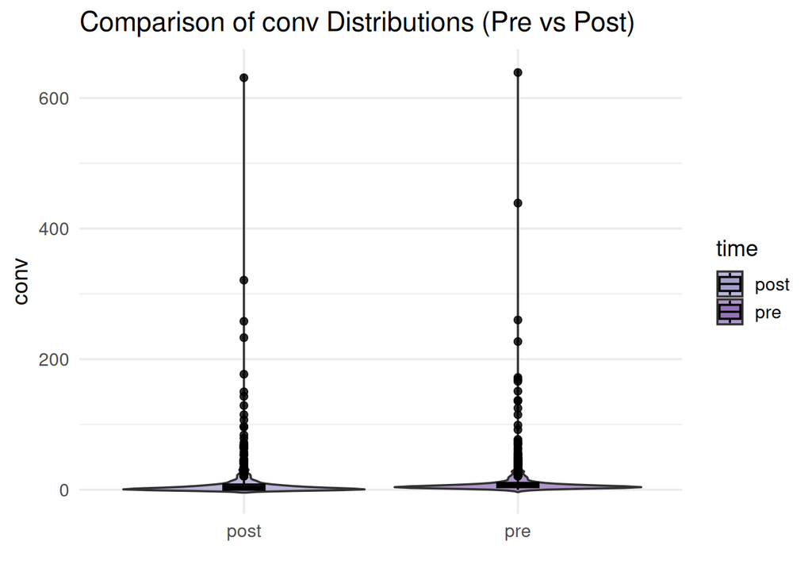

```r
data_b |>
  filter(platform == "m", time %in% c("pre", "post")) |>
  ggplot(aes(x = time, y = conv, fill = time)) +
  geom_violin(trim = FALSE, alpha = 0.7) +
  geom_boxplot(width = 0.15, color = "black", alpha = 0.8) +
  scale_fill_manual(values = c("pre" = "#8C6BB1", "post" = "#9E9AC8")) +
  labs(
    title = "Comparison of conv Distributions (Pre vs Post)",
    x = "",
    y = "conv"
  ) +
  theme_minimal(base_size = 14)
```

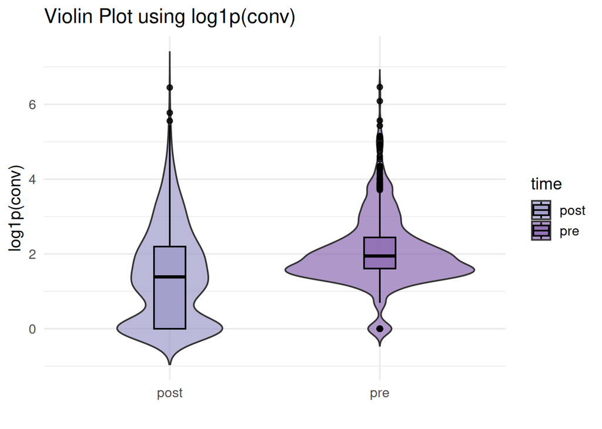

```r
data_b |>
  filter(platform == "m", time %in% c("pre", "post")) |>
  mutate(conv_log = log1p(conv)) |>
  ggplot(aes(x = time, y = conv_log, fill = time)) +
  geom_violin(trim = FALSE, alpha = 0.7) +
  geom_boxplot(width = 0.15, color = "black", alpha = 0.8) +
  scale_fill_manual(values = c("pre" = "#8C6BB1", "post" = "#9E9AC8")) +
  labs(
    title = "Violin Plot using log1p(conv)",
    x = "",
    y = "log1p(conv)"
  ) +
  theme_minimal(base_size = 14)
```

## 4.1 Question

> applied A/B testing on conversion rate

## 4.2 Ans

As what announce above, the familliar t-test wont be use directly, Let’s try a data-driven method that i learned 4 weeks ago: Boostrap test on mean.

We state our hypothesis:

$$\begin{aligned}
H_0: \ \mu_{\text{platform A}} &= \mu_{\text{platform B}} \\
H_1: \ \mu_{\text{platform A}} &\neq \mu_{\text{platform B}}
\end{aligned}$$

where $\mu_{\text{platform A}}$ and $\mu_{\text{platform B}}$ represent the true mean conversion rates of each platform.

```r
set.seed(42)

conv_m <- data_b |>
  filter(platform == "m") |>
  select(conv) |>
  pull()

conv_d <- data_b |>
  filter(platform == "d") |>
  select(conv) |>
  pull()

observed_diff <- abs(mean(conv_m,na.rm = TRUE) - mean(conv_d,na.rm = TRUE))
cat(sprintf("Sự khác biệt Quan sát (B - A): %.4f\n\n", observed_diff))
```

```
## Sự khác biệt Quan sát (B - A): 16.1756
```

Vòng lặp Bootstrap

```r
n_m <- length(conv_m)
n_d <- length(conv_d)
N_total <- n_m + n_d

num_bootstraps <- 10000
diffs_simulated <- numeric(num_bootstraps)

cat(sprintf("Boostraping (%d times)...\n", num_bootstraps))
```

```
## Boostraping (10000 times)...
```

```r
conv_m_til <- conv_m - mean(conv_m,na.rm = TRUE)
conv_d_til <- conv_d -mean(conv_d,na.rm = TRUE)

conv_sm <- sd(conv_m,na.rm = TRUE)
conv_sd <- sd(conv_d,na.rm = TRUE)


for (i in 1:num_bootstraps) {
  sample_m <- sample(conv_m_til,
                     size = n_m,
                     replace = TRUE)

  sample_d <- sample(conv_d_til,
                     size = n_d,
                     replace = TRUE)


  # Tính và lưu lại sự khác biệt của mẫu mô phỏng
  diffs_simulated[i] <- (mean(sample_m,na.rm = TRUE) - mean(sample_d,na.rm = TRUE))/sqrt((sd(sample_m,na.rm = TRUE)^2)/n_m + (sd(sample_d,na.rm = TRUE)^2)/n_d )
}

cat("Done.\n\n")
```

```
## Done.
```

Tính P-Value và Kết luận —

```r
T_obs <- observed_diff/sqrt((conv_sm^2)/n_m + (conv_sd^2)/n_d )

p_value <- sum(abs(diffs_simulated) >= abs(T_obs)) / num_bootstraps

# In kết quả
cat("--- Kết quả Kiểm tra Bootstrap Shift Method ---\n")
```

```
## --- Kết quả Kiểm tra Bootstrap Shift Method ---
```

```r
cat(sprintf("Observed Statistic (Y_bar1 - Y_bar2): %.4f\n", T_obs))
```

```
## Observed Statistic (Y_bar1 - Y_bar2): 6.6815
```

```r
cat(sprintf("Bootstrap P-Value (Hai phía): %.4f\n", p_value))
```

```
## Bootstrap P-Value (Hai phía): 0.0000
```

```r
# Kiểm tra P-Value
if (p_value < 0.05) {
  cat("\nKết luận: P-value < 0.05. Bác bỏ H0. Có sự khác biệt có ý nghĩa thống kê giữa mu1 và mu2.\n")
} else {
  cat("\nKết luận: P-value >= 0.05. Không bác bỏ H0. Không có đủ bằng chứng về sự khác biệt.\n")
}
```

```
##
## Kết luận: P-value < 0.05. Bác bỏ H0. Có sự khác biệt có ý nghĩa thống kê giữa mu1 và mu2.
```

```r
abs(T_obs)
```

```
## [1] 6.68146
```

```r
max(abs(diffs_simulated))
```

```
## [1] 5.500124
```

## 5.1 Question

> Utilize the data in terms of ROI. Do the Exploratory Data Anaysis.

## 5.2 Ans

```r
data_b <- data_b|>
  mutate(roi = value/cost)

m_stats <- data_b |>
  filter(platform == "m", time %in% c("pre", "post")) |>
  group_by(time) |>
  summarise(across(
    roi,
    list(
      mean = mean,
      median = median,
      sd = sd,
      min = min,
      max = max
    ),
    na.rm = TRUE,
    .names = "{.fn}"
  ))

m_stats
```

```
## # A tibble: 2 × 6
##   time   mean median    sd   min   max
##   <chr> <dbl>  <dbl> <dbl> <dbl> <dbl>
## 1 post   1.06  0.505  3.21     0  64.4
## 2 pre    1.66  1.09   1.93     0  15.6
```

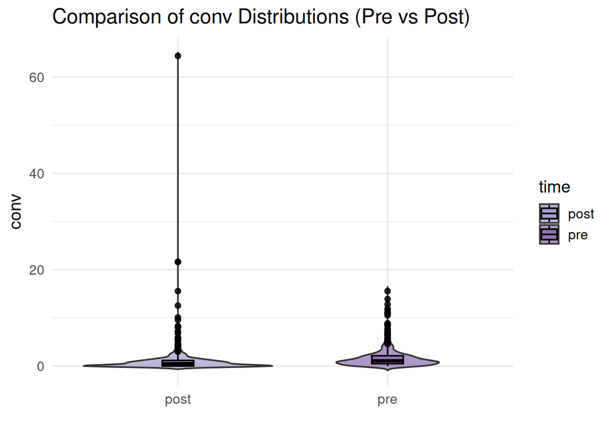

```r
data_b |>
  filter(platform == "m", time %in% c("pre", "post")) |>
  ggplot(aes(x = time, y = roi, fill = time)) +
  geom_violin(trim = FALSE, alpha = 0.7) +
  geom_boxplot(width = 0.15, color = "black", alpha = 0.8) +
  scale_fill_manual(values = c("pre" = "#8C6BB1", "post" = "#9E9AC8")) +
  labs(
    title = "Comparison of conv Distributions (Pre vs Post)",
    x = "",
    y = "conv"
  ) +
  theme_minimal(base_size = 14)
```

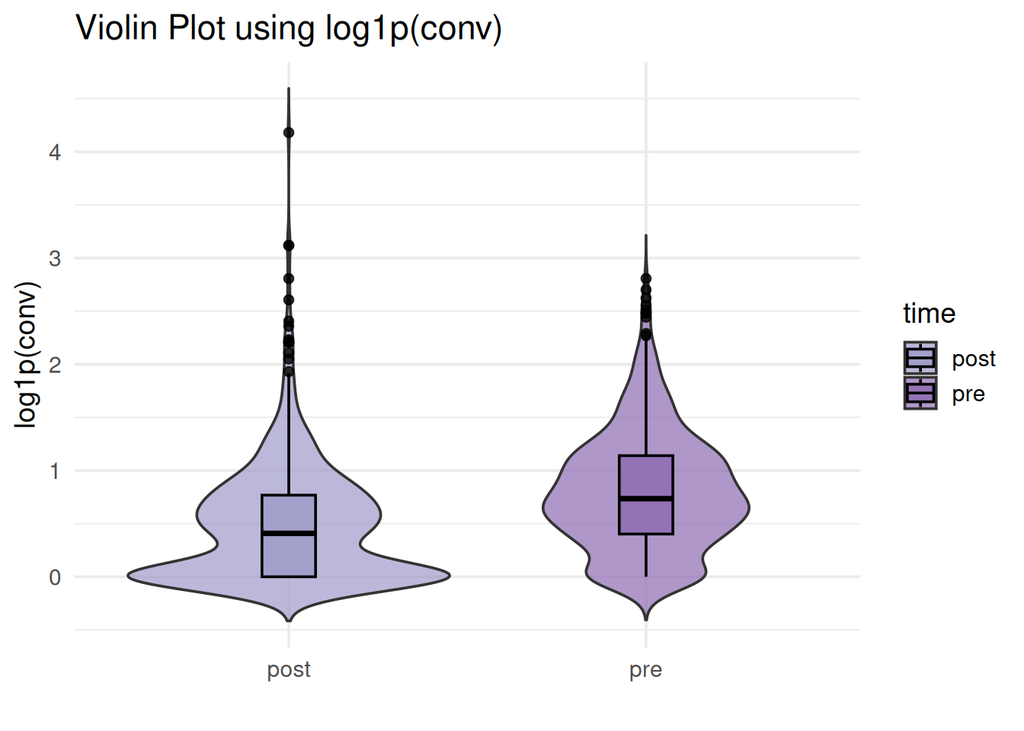

```r
data_b |>
  filter(platform == "m", time %in% c("pre", "post")) |>
  mutate(roi_log = log1p(roi)) |>
  ggplot(aes(x = time, y = roi_log, fill = time)) +
  geom_violin(trim = FALSE, alpha = 0.7) +
  geom_boxplot(width = 0.15, color = "black", alpha = 0.8) +
  scale_fill_manual(values = c("pre" = "#8C6BB1", "post" = "#9E9AC8")) +
  labs(
    title = "Violin Plot using log1p(conv)",
    x = "",
    y = "log1p(conv)"
  ) +
  theme_minimal(base_size = 14)
```

- **Median Decline:** The median $\text{log1p}(\text{conv})$ **dropped** from ‘pre’ (approx. 0.75) to ‘post’ (belơ 0.5). This signifies that the **typical, or average, the ROI rates decreased** following the change.
- **Increased Volatility (Risk):** The **‘post’** distribution shows **higher variability** and a pronounced, thin upper tail. This indicates the change introduced **greater performance volatility** and a **higher concentration of low/zero-conversion events** alongside a few extreme high performers.

In conclusion The experiment **negatively impacted the consistency and average performance**, leading to **lower generalized ROI** and introducing **higher risk** (volatility) in the conversion outcomes across the platform(s).

## 5.2 Ans

As what announce above, the familliar t-test wont be use directly, Let’s try a data-driven method that i learned 4 weeks ago: Boostrap test on mean.

We state our hypothesis:

$$\begin{aligned}
H_0: \ \mu_{\text{ROI A}} &= \mu_{\text{ROI B}} \\
H_1: \ \mu_{\text{ROI A}} &\neq \mu_{\text{ROI B}}
\end{aligned}$$

```r
set.seed(42)

roi_m <- data_b |>
  filter(platform == "m") |>
  select(roi) |>
  pull()

roi_d <- data_b |>
  filter(platform == "d") |>
  select(roi) |>
  pull()

observed_diff <- abs(mean(roi_m,na.rm = TRUE) - mean(roi_d,na.rm = TRUE))
cat(sprintf("Sự khác biệt Quan sát (B - A): %.4f\n\n", observed_diff))
```

```
## Sự khác biệt Quan sát (B - A): 0.0126
```

Vòng lặp Bootstrap

```r
mean(roi_m,na.rm = TRUE)
```

```
## [1] 1.369562
```

```r
n_m <- length(roi_m)
n_d <- length(roi_d)
N_total <- n_m + n_d

num_bootstraps <- 10000
diffs_simulated <- numeric(num_bootstraps)

cat(sprintf("Boostraping (%d times)...\n", num_bootstraps))
```

```
## Boostraping (10000 times)...
```

```r
roi_sm <- sd(roi_m,na.rm = TRUE)
roi_sd <- sd(roi_d,na.rm = TRUE)

roi_m_til <- roi_m - mean(roi_m,na.rm = TRUE)
roi_d_til <- roi_d -mean(roi_d,na.rm = TRUE)




for (i in 1:num_bootstraps) {
  sample_m <- sample(roi_m_til,
                     size = n_m,
                     replace = TRUE)

  sample_d <- sample(roi_d_til,
                     size = n_d,
                     replace = TRUE)


  # Tính và lưu lại sự khác biệt của mẫu mô phỏng
  diffs_simulated[i] <- (mean(sample_m,na.rm = TRUE) - mean(sample_d,na.rm = TRUE))/sqrt((sd(sample_m,na.rm = TRUE)^2)/n_m + (sd(sample_d,na.rm = TRUE)^2)/n_d )
}

cat("Done.\n\n")
```

```
## Done.
```

Tính P-Value và Kết luận —

```r
T_obs <- observed_diff/sqrt((roi_sm^2)/n_m + (roi_sd^2)/n_d )

p_value <- sum(abs(diffs_simulated) >= abs(T_obs)) / num_bootstraps

# In kết quả
cat("--- Kết quả Kiểm tra Bootstrap Shift Method ---\n")
```

```
## --- Kết quả Kiểm tra Bootstrap Shift Method ---
```

```r
cat(sprintf("Observed Statistic (Y_bar1 - Y_bar2): %.4f\n", T_obs))
```

```
## Observed Statistic (Y_bar1 - Y_bar2): 0.1461
```

```r
cat(sprintf("Bootstrap P-Value (Hai phía): %.4f\n", p_value))
```

```
## Bootstrap P-Value (Hai phía): 0.8850
```

```r
# Kiểm tra P-Value
if (p_value < 0.05) {
  cat("\nKết luận: P-value < 0.05. Bác bỏ H0. Có sự khác biệt có ý nghĩa thống kê giữa mu1 và mu2.\n")
} else {
  cat("\nKết luận: P-value >= 0.05. Không bác bỏ H0. Không có đủ bằng chứng về sự khác biệt.\n")
}
```

```
##
## Kết luận: P-value >= 0.05. Không bác bỏ H0. Không có đủ bằng chứng về sự khác biệt.
```